# Praktikum 3 MPDW

Panji Elang Permanajati

2026-09-09

# Packages

```r
library(dLagM)
library(dynlm)
library(MLmetrics)
library(lmtest)
library(car)
library(rio)
library(readxl)
data <- read.csv("C:\\Users\\darmo\\Downloads\\NewDelhi_Air_quality (1).csv")
data <- data[order(data$ts), ]
data$t <- 1:nrow(data)
str(data)
```

```
## 'data.frame':    72 obs. of  13 variables:
##  $ X              : int  0 1 2 3 4 5 6 7 8 9 ...
##  $ AQI            : num  30.2 28.2 26.6 25 26 26 26 24 23 24 ...
##  $ CO             : num  199 198 199 202 205 ...
##  $ datetime       : chr  "2022-10-21:18" "2022-10-21:19" "2022-10-21:20" "2022-10-21:21" ...
##  $ no2            : num  0.0469 0.0465 0.0469 0.0482 0.0489 ...
##  $ o3             : num  55.8 54.9 54.6 55.1 55.8 ...
##  $ pm10           : num  10.5 10.7 11.2 11.1 10.4 ...
##  $ pm25           : num  5.64 4.62 3.52 2.23 1.98 ...
##  $ so2            : num  0.387 0.41 0.402 0.376 0.339 ...
##  $ timestamp_local: chr  "2022-10-21T23:00:00" "2022-10-22T00:00:00" "2022-10-22T01:00:00" "2022-10-22T02:00:00" ...
##  $ timestamp_utc  : chr  "2022-10-21T18:00:00" "2022-10-21T19:00:00" "2022-10-21T20:00:00" "2022-10-21T21:00:00" ...
##  $ ts             : int  1666375200 1666378800 1666382400 1666386000 1666389600 1666393200 1666396800 1666400400 1666404000 1666407600 ...
##  $ t              : int  1 2 3 4 5 6 7 8 9 10 ...
```

```r
head(data)
```

```
##   X  AQI       CO      datetime        no2       o3      pm10     pm25
## 1 0 30.2 198.6027 2022-10-21:18 0.04685717 55.78995 10.486722 5.637410
## 2 1 28.2 197.6013 2022-10-21:19 0.04645554 54.93164 10.719325 4.618169
## 3 2 26.6 198.6027 2022-10-21:20 0.04685717 54.64554 11.155578 3.520902
## 4 3 25.0 201.9405 2022-10-21:21 0.04819594 55.07469 11.116206 2.225919
## 5 4 26.0 205.2784 2022-10-21:22 0.04886533 55.78995 10.405250 1.979471
## 6 5 26.0 208.6163 2022-10-21:23 0.05020411 56.50520  9.402518 1.792677
##         so2     timestamp_local       timestamp_utc         ts t
## 1 0.3874302 2022-10-21T23:00:00 2022-10-21T18:00:00 1666375200 1
## 2 0.4097819 2022-10-22T00:00:00 2022-10-21T19:00:00 1666378800 2
## 3 0.4023313 2022-10-22T01:00:00 2022-10-21T20:00:00 1666382400 3
## 4 0.3762543 2022-10-22T02:00:00 2022-10-21T21:00:00 1666386000 4
## 5 0.3390014 2022-10-22T03:00:00 2022-10-21T22:00:00 1666389600 5
## 6 0.3129244 2022-10-22T04:00:00 2022-10-21T23:00:00 1666393200 6
```

# Pemilihan Peubah Independen

```r
polutan <- data[, c("CO", "no2", "o3", "pm10", "pm25", "so2")]
korelasi <- sapply(polutan, function(x) cor(data$AQI, x))
sort(korelasi, decreasing = TRUE)
```

```
##          o3          CO         no2        pm10        pm25         so2
##  0.97359901  0.79763320  0.73765472  0.08257568 -0.34665524 -0.74247813
```

Polutan CO (Karbon Monoksida) memiliki tingkat korelasi positif yang sangat kuat terhadap AQI (sekitar $r = 0,798$). Hal ini mengindikasikan bahwa peningkatan konsentrasi emisi gas kendaraan dan pembakaran (CO) secara signifikan mendorong kenaikan Indeks Kualitas Udara (AQI) di Kota New Delhi.

```r
data$Yt <- data$AQI
data$Xt <- data$CO
```

# Pembagian Data Train dan Test

```r
n <- nrow(data)
n_train <- round(0.75 * n)

train <- data[1:n_train, ]
test  <- data[(n_train + 1):n, ]

x_train <- as.vector(train$Xt)
y_train <- as.vector(train$Yt)
x_test  <- as.vector(test$Xt)
y_test  <- as.vector(test$Yt)

train.ts <- ts(train)
test.ts  <- ts(test)

c(n_total = n, n_train = nrow(train), n_test = nrow(test))
```

```
## n_total n_train  n_test
##      72      54      18
```

# Model Koyck

```r
model.koyck <- koyckDlm(x = x_train, y = y_train)
summary(model.koyck)
```

```
##
## Call:
## "Y ~ (Intercept) + Y.1 + X.t"
##
## Residuals:
##      Min       1Q   Median       3Q      Max
## -2.01328 -0.49464  0.03244  0.58868  2.27048
##
## Coefficients:
##             Estimate Std. Error t value Pr(>|t|)
## (Intercept)  5.28397   10.04682   0.526    0.601
## Y.1          0.90541    0.08492  10.662 1.78e-14 ***
## X.t         -0.01370    0.05734  -0.239    0.812
## ---
## Signif. codes:  0 '***' 0.001 '**' 0.01 '*' 0.05 '.' 0.1 ' ' 1
##
## Residual standard error: 0.9469 on 50 degrees of freedom
## Multiple R-Squared: 0.8177,  Adjusted R-squared: 0.8104
## Wald test: 112.7 on 2 and 50 DF,  p-value: < 2.2e-16
##
## Diagnostic tests:
## NULL
##
##                             alpha        beta       phi
## Geometric coefficients:  55.86447 -0.01369588 0.9054144
```

```r
aic_koyck <- AIC(model.koyck)
```

```
## [1] 149.5384
```

```r
bic_koyck <- BIC(model.koyck)
```

```
## [1] 157.4196
```

## Peramalan dan Akurasi Model Koyck

```r
fore.koyck <- forecast(model = model.koyck, x = x_test, h = nrow(test))
fore.koyck
```

```
## $forecasts
##  [1] 27.01012 27.01929 27.02759 27.03510 27.06476 27.13733 27.20304 27.28539
##  [9] 27.35995 27.42745 27.48858 27.54392 27.59402 27.61653 27.61406 27.58896
## [17] 27.54337 27.50210
##
## $call
## forecast.koyckDlm(model = model.koyck, x = x_test, h = nrow(test))
##
## attr(,"class")
## [1] "forecast.koyckDlm" "dLagM"
```

```r
mape_koyck <- MAPE(fore.koyck$forecasts, y_test) * 100
mape_koyck
```

```
## [1] 21.47603
```

```r
GoF(model.koyck)
```

```
##              n     MAE         MPE       MAPE      sMAPE     MASE       MSE
## model.koyck 53 0.69404 -0.00111704 0.02563878 0.02556194 1.087051 0.8459109
##                  MRAE    GMRAE
## model.koyck 799356386 12045.11
```

# Regression with Distributed Lag (DLM)

Model distributed lag memasukkan peubah X pada waktu sekarang beserta beberapa lag-nya sebagai prediktor. Penentuan panjang lag optimum (q) dilakukan menggunakan finiteDLMauto() berdasarkan kriteria AIC.

```r
opt.dlm <- finiteDLMauto(formula = Yt ~ Xt, data = data.frame(train),
                         q.min = 1, q.max = 6, model.type = "dlm",
                         error.type = "AIC", trace = FALSE)
opt.dlm
```

```
##   q - k    MASE      AIC      BIC    GMRAE   MBRAE R.Adj.Sq    Ljung-Box
## 6     6 1.45948 181.2925 198.1333 22563.36 1.40767  0.58048 2.665961e-05
```

Berdasarkan hasil pencarian di atas, panjang lag optimum dipilih pada nilai AIC terendah. Pemodelan selanjutnya menggunakan panjang lag optimum tersebut.

```r
q_opt <- as.numeric(rownames(opt.dlm[which.min(opt.dlm$AIC), ]))
model.dlm <- dlm(x = x_train, y = y_train, q = q_opt)
summary(model.dlm)
```

```
##
## Call:
## lm(formula = model.formula, data = design)
##
## Residuals:
##     Min      1Q  Median      3Q     Max
## -4.7179 -0.4716  0.0555  0.7460  3.6565
##
## Coefficients:
##             Estimate Std. Error t value Pr(>|t|)
## (Intercept) -50.1133    16.5290  -3.032  0.00425 **
## x.t           0.7833     0.1777   4.408 7.63e-05 ***
## x.1          -0.2025     0.2924  -0.693  0.49258
## x.2          -0.3375     0.2858  -1.181  0.24462
## x.3           0.2076     0.3034   0.684  0.49766
## x.4           0.1845     0.2866   0.644  0.52357
## x.5          -0.2741     0.2939  -0.933  0.35667
## x.6           0.0229     0.1694   0.135  0.89314
## ---
## Signif. codes:  0 '***' 0.001 '**' 0.01 '*' 0.05 '.' 0.1 ' ' 1
##
## Residual standard error: 1.452 on 40 degrees of freedom
## Multiple R-squared:  0.643,  Adjusted R-squared:  0.5805
## F-statistic: 10.29 on 7 and 40 DF,  p-value: 2.662e-07
##
## AIC and BIC values for the model:
##        AIC      BIC
## 1 181.2925 198.1333
```

```r
aic_dlm <- AIC(model.dlm)
```

```
## [1] 181.2925
```

```r
bic_dlm <- BIC(model.dlm)
```

```
## [1] 198.1333
```

## Peramalan dan Akurasi Model DLM

```r
fore.dlm <- forecast(model = model.dlm, x = x_test, h = nrow(test))
fore.dlm
```

```
## $forecasts
##  [1] 25.94081 25.82135 26.42288 26.07637 24.46128 22.64209 23.84304 23.31590
##  [9] 22.65297 23.05802 23.58808 23.20380 23.66120 24.93023 25.89956 26.30557
## [17] 27.05810 26.81120
##
## $call
## forecast.dlm(model = model.dlm, x = x_test, h = nrow(test))
##
## attr(,"class")
## [1] "forecast.dlm" "dLagM"
```

```r
mape_dlm <- MAPE(fore.dlm$forecasts, y_test) * 100
mape_dlm
```

```
## [1] 10.08289
```

```r
GoF(model.dlm)
```

```
##            n       MAE          MPE      MAPE      sMAPE     MASE      MSE
## model.dlm 48 0.9005289 -0.002319119 0.0332266 0.03279871 1.459478 1.757776
##                 MRAE    GMRAE
## model.dlm 3258222208 22563.36
```

# Model Autoregressive Distributed Lag (ARDL)

Model ARDL memasukkan baik lag dari peubah dependen (Y) maupun lag dari peubah independen (X) sekaligus. Penentuan orde optimum (p untuk lag X, q untuk lag Y) dilakukan menggunakan ardlBoundOrders() berdasarkan kriteria AIC.

```r
model.ardl.opt <- ardlBoundOrders(data = data.frame(train), ic = "AIC", formula = Yt ~ Xt)
p_opt <- model.ardl.opt$p$Xt
```

```r
q_opt_ardl <- model.ardl.opt$q
q_opt_ardl
```

```
## [1] 15
```

Berdasarkan pencarian tersebut, diperoleh kombinasi orde optimum yang selanjutnya digunakan untuk membangun model ARDL final.

```r
model.ardl <- ardlDlm(formula = Yt ~ Xt, data = train, p = p_opt, q = q_opt_ardl)
summary(model.ardl)
```

```
##
## Time series regression with "ts" data:
## Start = 16, End = 54
##
## Call:
## dynlm(formula = as.formula(model.text), data = data)
##
## Residuals:
##      Min       1Q   Median       3Q      Max
## -0.55083 -0.19392  0.02982  0.12988  0.78399
##
## Coefficients:
##               Estimate Std. Error t value Pr(>|t|)
## (Intercept) -38.991304  26.678670  -1.462   0.1779
## Xt.t          0.328852   0.140231   2.345   0.0437 *
## Xt.1          0.076512   0.178201   0.429   0.6778
## Xt.2         -0.091429   0.177347  -0.516   0.6186
## Xt.3          0.017354   0.198795   0.087   0.9323
## Xt.4          0.092196   0.214679   0.429   0.6777
## Xt.5         -0.199558   0.220607  -0.905   0.3893
## Xt.6          0.256083   0.229210   1.117   0.2928
## Xt.7          0.246683   0.276242   0.893   0.3951
## Xt.8         -0.532024   0.288020  -1.847   0.0978 .
## Xt.9          0.304339   0.267182   1.139   0.2841
## Xt.10         0.118076   0.208085   0.567   0.5843
## Xt.11        -0.271274   0.191963  -1.413   0.1912
## Xt.12         0.005646   0.201466   0.028   0.9783
## Xt.13        -0.027020   0.152327  -0.177   0.8631
## Yt.1          0.332435   0.294439   1.129   0.2881
## Yt.2          0.329584   0.338368   0.974   0.3555
## Yt.3         -0.101082   0.322275  -0.314   0.7609
## Yt.4         -0.097019   0.326704  -0.297   0.7732
## Yt.5          0.050094   0.346486   0.145   0.8882
## Yt.6         -0.770804   0.369464  -2.086   0.0666 .
## Yt.7          0.235307   0.394237   0.597   0.5653
## Yt.8          0.134930   0.358412   0.376   0.7153
## Yt.9         -0.114166   0.326738  -0.349   0.7348
## Yt.10        -0.037687   0.364941  -0.103   0.9200
## Yt.11        -0.214812   0.351279  -0.612   0.5560
## Yt.12         0.352068   0.358254   0.983   0.3514
## Yt.13        -0.046566   0.340273  -0.137   0.8942
## Yt.14         0.395647   0.362167   1.092   0.3030
## Yt.15        -0.395432   0.205479  -1.924   0.0864 .
## ---
## Signif. codes:  0 '***' 0.001 '**' 0.01 '*' 0.05 '.' 0.1 ' ' 1
##
## Residual standard error: 0.5572 on 9 degrees of freedom
## Multiple R-squared:  0.9842, Adjusted R-squared:  0.9333
## F-statistic: 19.34 on 29 and 9 DF,  p-value: 3.472e-05
```

```r
aic_ardl <- AIC(model.ardl)
```

```
## [1] 69.87409
```

```r
bic_ardl <- BIC(model.ardl)
```

```
## [1] 121.4445
```

## Peramalan dan Akurasi Model ARDL

```r
fore.ardl <- forecast(model = model.ardl, x = x_test, h = nrow(test))
fore.ardl
```

```
## $forecasts
##  [1] 27.54999 27.03592 27.40079 26.88928 25.12624 25.68116 23.72658 23.11747
##  [9] 22.09388 21.97089 23.37837 21.89433 23.73336 24.73281 25.99073 27.97214
## [17] 28.15546 30.67356
##
## $call
## forecast.ardlDlm(model = model.ardl, x = x_test, h = nrow(test))
##
## attr(,"class")
## [1] "forecast.ardlDlm" "dLagM"
```

```r
mape_ardl <- MAPE(fore.ardl$forecasts, y_test) * 100
mape_ardl
```

```
## [1] 11.45598
```

```r
GoF(model.ardl)
```

```
##             n       MAE           MPE        MAPE       sMAPE      MASE
## model.ardl 39 0.2070751 -8.500766e-05 0.007419304 0.007419823 0.3934427
##                   MSE      MRAE    GMRAE
## model.ardl 0.07164891 959099821 23689.74
```

Model ARDL menggabungkan pengaruh historis AQI sendiri ($Y_{t-q}$) dan akumulasi pengaruh CO ($X_{t-p}$). Dengan mengakomodasi dinamika dari kedua belah pihak, model ARDL mampu menekan nilai sisaan (residual error) sehingga menghasilkan kriteria AIC/BIC yang paling minim pada data latih.

# Perbandingan dan Pemilihan Model

```r
perbandingan <- data.frame(
  Model = c("Koyck", paste0("DLM (q=", q_opt, ")"), paste0("ARDL (p=", p_opt, ", q=", q_opt_ardl, ")")),
  AIC = c(aic_koyck, aic_dlm, aic_ardl),
  BIC = c(bic_koyck, bic_dlm, bic_ardl),
  MAPE_Test = c(mape_koyck, mape_dlm, mape_ardl)
)
perbandingan
```

```
##               Model       AIC      BIC MAPE_Test
## 1             Koyck 149.53840 157.4196  21.47603
## 2         DLM (q=6) 181.29246 198.1333  10.08289
## 3 ARDL (p=13, q=15)  69.87409 121.4445  11.45598
```

```r
dev_koyck <- sum(residuals(model.koyck)^2, na.rm = TRUE)
```

[output not shown]

```r
dev_dlm   <- sum(residuals(model.dlm)^2, na.rm = TRUE)
```

[output not shown]

```r
dev_ardl  <- sum(residuals(model.ardl)^2, na.rm = TRUE)
```

[output not shown]

# Evaluasi (Uji Asumsi) Model

```r
model.dyn <- dynlm(Yt ~ Xt + L(Xt) + L(Yt), data = train.ts)

dwtest(model.dyn)
```

```
##
##  Durbin-Watson test
##
## data:  model.dyn
## DW = 1.3765, p-value = 0.003839
## alternative hypothesis: true autocorrelation is greater than 0
```

```r
bptest(model.dyn)
```

```
##
##  studentized Breusch-Pagan test
##
## data:  model.dyn
## BP = 2.0854, df = 3, p-value = 0.5549
```

```r
shapiro.test(residuals(model.dyn))
```

```
##
##  Shapiro-Wilk normality test
##
## data:  residuals(model.dyn)
## W = 0.98607, p-value = 0.79
```

1. Uji Autokorelasi (Durbin-Watson Test):

Pengujian menghasilkan nilai statistik $DW = 1,3765$ dengan $p\text{-value} = 0,003839$. Karena $p\text{-value} < 0,05$, maka keputusan yang diambil adalah tolak $H_0$. Hal ini menunjukkan bahwa terdapat gejala autokorelasi positif pada sisaan model. Adanya autokorelasi ini mengindikasikan masih terdapat pola runtun waktu yang belum sepenuhnya terjelaskan oleh peubah lag dalam model.

2. Uji Heteroskedastisitas (Breusch-Pagan Test):

Diperoleh nilai statistik $BP = 2,0854$ ($df = 3$) dengan $p\text{-value} = 0,5549$. Karena $p\text{-value} > 0,05$, maka gagal tolak $H_0$. Ini berarti asumsi homoskedastisitas terpenuhi (ragam sisaan bernilai konstan atau homogen).

3. Uji Normalitas (Shapiro-Wilk Test):

Hasil pengujian menunjukkan nilai statistik $W = 0,98607$ dengan $p\text{-value} = 0,7900$. Karena $p\text{-value} > 0,05$, keputusan yang diambil adalah gagal tolak $H_0$, yang berarti sisaan menyebar normal.

# Visualisasi Grafik Peramalan

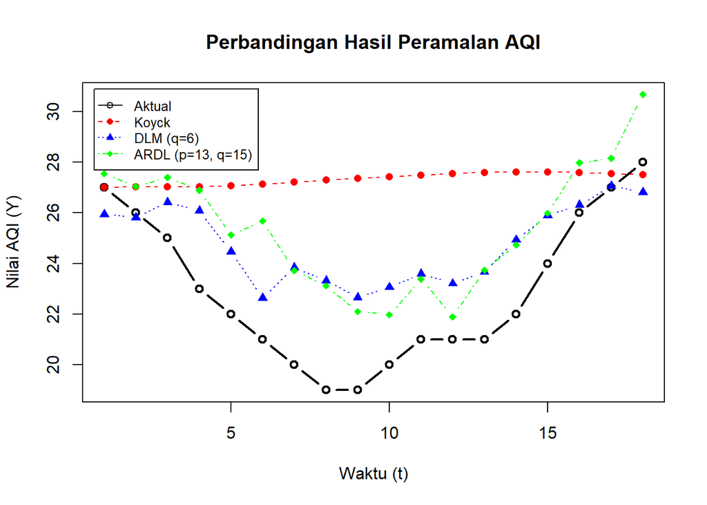

```r
par(mfrow = c(1, 1))

# Plot nilai aktual AQI pada data test
plot(y_test, type = "b", col = "black", lwd = 2, pch = 1,
     ylab = "Nilai AQI (Y)", xlab = "Waktu (t)",
     main = "Perbandingan Hasil Peramalan AQI",
     ylim = range(c(y_test, fore.koyck$forecasts, fore.dlm$forecasts, fore.ardl$forecasts)))

lines(fore.koyck$forecasts, col = "red", type = "b", pch = 16, lty = 2)
lines(fore.dlm$forecasts, col = "blue", type = "b", pch = 17, lty = 3)
lines(fore.ardl$forecasts, col = "green", type = "b", pch = 18, lty = 4)

legend("topleft",
       legend = c("Aktual", "Koyck", paste0("DLM (q=", q_opt, ")"), paste0("ARDL (p=", p_opt, ", q=", q_opt_ardl, ")")),
       col = c("black", "red", "blue", "green"),
       lty = c(1, 2, 3, 4), pch = c(1, 16, 17, 18), cex = 0.8, inset = 0.02)
```

Secara visual, Model DLM ($q=6$) dan ARDL ($p=13, q=15$) jauh lebih unggul daripada Model Koyck dalam memodelkan pola perubahan AQI. Model DLM dan ARDL terbukti mampu merepresentasikan tren penurunan dan kenaikan data aktual secara dinamis, sementara Model Koyck gagal menyesuaikan diri terhadap perubahan pola data masa depan.

# Tabel Perbandingan Metrik Evaluasi

```r
perbandingan <- data.frame(
  Model = c("Koyck", paste0("DLM (q=", q_opt, ")"), paste0("ARDL (p=", p_opt, ", q=", q_opt_ardl, ")")),
  AIC = c(aic_koyck, aic_dlm, aic_ardl),
  BIC = c(bic_koyck, bic_dlm, bic_ardl),
  Deviance_SSE = c(dev_koyck, dev_dlm, dev_ardl),
  MAPE_Test = c(mape_koyck, mape_dlm, mape_ardl)
)

perbandingan
```

```
##               Model       AIC      BIC Deviance_SSE MAPE_Test
## 1             Koyck 149.53840 157.4196    44.833278  21.47603
## 2         DLM (q=6) 181.29246 198.1333    84.373227  10.08289
## 3 ARDL (p=13, q=15)  69.87409 121.4445     2.794308  11.45598
```

Berdasarkan hasil evaluasi ketiga model regresi dengan peubah lag:

1. Model Koyck menghasilkan nilai kriteria kebaikan model yang relatif tinggi (AIC = 149,54; BIC = 157,42) dan tingkat kesalahan peramalan data uji paling besar (MAPE = 21,48%). Hal ini mengindikasikan bahwa asumsi penurunan lag secara geometris pada Koyck kurang fleksibel dalam memodelkan dinamika hubungan antara konsentrasi CO dan AQI.
2. Model Distributed Lag (DLM $q=6$) memberikan tingkat kesalahan peramalan pada data uji (out-of-sample) yang paling presisi, yaitu dengan MAPE sebesar 10,08%. Hal ini menunjukkan bahwa akumulasi lag CO hingga 6 jam sebelumnya sangat efektif dalam memprediksi fluktuasi AQI ke depan.
3. Model Autoregressive Distributed Lag (ARDL $p=13, q=15$) berhasil memberikan performa goodness-of-fit terbaik pada data latih (in-sample) yang ditandai dengan nilai AIC (69,87) dan BIC (121,44) terkecil di antara ketiga model, serta nilai MAPE data uji yang juga sangat baik (11,46%).

Jika mengutamakan kriteria kebaikan model secara keseluruhan (goodness-of-fit dan efisiensi parameter pada data latih), Model ARDL ($p=13, q=15$) terpilih sebagai model terbaik karena memiliki nilai AIC dan BIC paling minimum. Namun, jika fokus utama pemodelan adalah presisi peramalan masa depan (forecasting), Model DLM ($q=6$) dapat dijadikan alternatif utama karena menghasilkan nilai MAPE data uji terendah (10,08%).

# Kesimpulan